# Bayesian Analysis of Gambling Warning: Risky Choice Experiment

Philip Newall, Lukasz Walasek, Henrik Singmann, Elliot Ludvig

2020-11-23

# Setup

```r
library("stanova")  ## remotes::install_github("bayesstuff/stanova")
library("brms")
library("emmeans")
library("tidyverse")
library("tidybayes")
theme_set(theme_bw(base_size = 15) +
            theme(legend.position="bottom"))
source("analysis_fun.R")
library("binom")
options(mc.cores = parallel::detectCores()) # fitting uses multicore by default
```

```r
din <- read_csv("data/Soccerwarnings1.csv",
                col_types = cols(
                  .default = col_double(),
                  gendertext = col_logical(),
                  comments = col_character(),
                  PROLIFIC_PID = col_character(),
                  ordercontrol = col_character(),
                  orderwarning = col_character()
                )) %>%
  mutate(newid = factor(1:nrow(.)))

dl <- din %>%
  select(newid, starts_with("control"), starts_with("warning")) %>%
  gather("condition", "response", -newid) %>%
  filter(!is.na(response)) %>%
  mutate(item = as.numeric(str_extract(condition, "\\d"))) %>%
  mutate(label = factor(str_remove(condition, "\\d"),
                            levels = c("warning", "control"))) %>%
  mutate(complexity = factor(case_when(
    item <= 3 ~ "low",
    item <= 6 ~ "medium",
    item <= 9 ~ "high",
    TRUE ~ NA_character_
  ), levels = c("low", "medium", "high")))
dl %>%
  group_by(newid) %>%
  summarise(check = mean(label == "control")) %>%
  {all(.$check %in% c(0, 1))} ## all newid in one condition only?
```

```
## [1] TRUE
```

Two (anonymized) IDs seem to have taken part in the experiment twice.

```r
ids <- table(din$PROLIFIC_PID)
ids[ ids > 1 ]
```

```
##
## 361cf24307b89e6ca5954f9fedd64fb0bdbdd8904055c34f0bb6479d513dc394
##                                                                2
## b96c613a6ceb9e343b259cbb69d0211527f3ac38cc3619908df1f80a50120b13
##                                                                2
```

We therefore exclude those participants from the data.

```r
ids_remove <- din %>%
  filter(PROLIFIC_PID %in% names(ids[ ids > 1 ])) %>%
  .$newid

dl <- dl %>%
  filter(!(newid %in% ids_remove))
```

# Demographics

```r
add_vars <- din %>%
  filter(!(newid %in% ids_remove)) %>%
  mutate(psg = rowSums(select(., starts_with("pgsi")))) %>%
  select(newid, gender, age, freq, psg) %>%
  mutate(gender = factor(gender, levels = 1:4,
                         labels = c("Male", "Female", "other", "no-answer")),
         age_z = get_z(age),
         freq_z = get_z(freq),
         psg_z = get_z(psg))
```

Gender distribution:

```r
any(!is.na(din$gendertext))
```

```
## [1] FALSE
```

```r
add_vars %>%
  group_by(gender) %>%
  tally() %>%
  mutate(p = n / sum(n))
```

```
## # A tibble: 3 x 3
##   gender     n       p
##   <fct>  <int>   <dbl>
## 1 Male     168 0.332
## 2 Female   337 0.666
## 3 <NA>       1 0.00198
```

Distribution of other covariates:

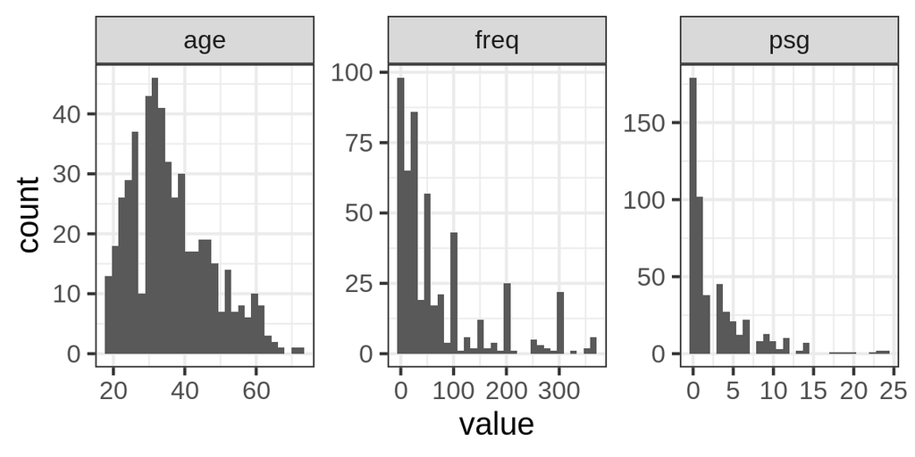

```r
add_vars %>%
  gather("variable", "value", psg, freq, age) %>%
  ggplot(aes(value)) +
  geom_histogram(bins = 30) +
  facet_wrap("variable", scales = "free")
```

```r
add_vars %>%
  select(psg, freq, age) %>%
  psych::describe()
```

```
##      vars   n  mean    sd median trimmed   mad min max range skew kurtosis   se
## psg     1 506  2.92  4.16    1.0    2.05  1.48   0  24    24 2.23     6.01 0.18
## freq    2 506 71.31 87.47   37.5   53.49 48.18   0 365   365 1.68     2.00 3.89
## age     3 506 36.12 11.15   34.0   35.24 10.38  18  72    54 0.68    -0.11 0.50
```

We can also inspect the inter-correlation among those:

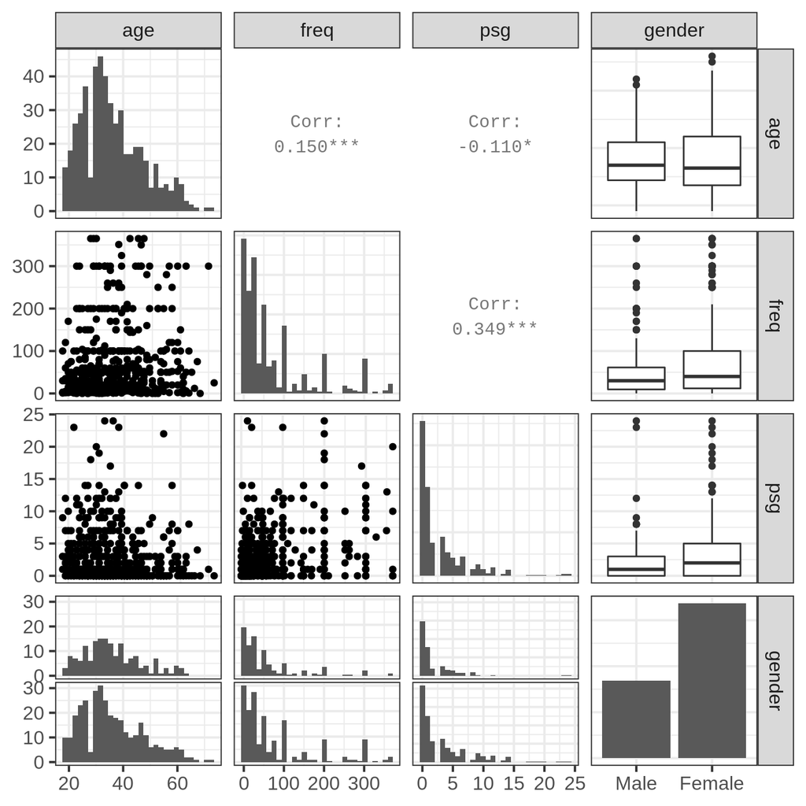

```r
add_vars %>%
  select(age, freq, psg, gender) %>%
  na.omit() %>%
  GGally::ggpairs(progress = FALSE, diag = list(continuous = "barDiag"))
```

# Descriptives

```r
dl %>%
  group_by(label) %>%
  summarise(c = list(binom.confint(sum(response), n = n()))) %>%
  unnest(c) %>%
  filter(method == "agresti-coull")
```

```
## # A tibble: 2 x 7
##   label   method            x     n  mean lower upper
##   <fct>   <chr>         <dbl> <dbl> <dbl> <dbl> <dbl>
## 1 warning agresti-coull   944  2286 0.413 0.393 0.433
## 2 control agresti-coull   857  2268 0.378 0.358 0.398
```

The descriptives show a slightly larger rate of choosing the gamble in the warning compared to the control condition.

```r
dl %>%
  group_by(complexity) %>%
  summarise(c = list(binom.confint(sum(response), n = n()))) %>%
  unnest(c) %>%
  filter(method == "agresti-coull")
```

```
## # A tibble: 3 x 7
##   complexity method            x     n  mean lower upper
##   <fct>      <chr>         <dbl> <dbl> <dbl> <dbl> <dbl>
## 1 low        agresti-coull   604  1518 0.398 0.374 0.423
## 2 medium     agresti-coull   531  1518 0.350 0.326 0.374
## 3 high       agresti-coull   666  1518 0.439 0.414 0.464
```

The influence of complexity does not appear to be overly strong or monotonic.

# Bayesian Mixed Models

We first need to aggregate the data to sample efficiently.

```r
dla <- dl %>%
  group_by(complexity, label, newid) %>%
  summarise(acc = mean(response),
            nsucc = sum(response == 1),
            nt = n()) %>%
  ungroup
```

## Models

### Full Fixed Effects

We begin with the maximal-model justified by the design which has by-participant random slopes and by-participant random slopes for complexity as well as correlation among the random-effect parameters.

The model shows no obvious problems.

```r
summary(mfull, diff_intercept = TRUE)
```

```
##
## Model Info:
##  function:     brms::brm
##  family:       binomial(logit)
##  formula:      nsucc | trials(nt) ~ label * complexity + (complexity | newid)
##  algorithm:    sampling
##  chains:       4
##  sample:       20000 (posterior sample size)
##  priors:       Use brms::prior_summary(object) for prior information
##  observations: 1518
##  groups:       newid (506)
##
## Estimate Intercept:
##      Variable   Mean MAD_SD     5%    50%    95%  rhat ess_bulk  ess_tail
## 1 (Intercept) -0.589  0.078 -0.718 -0.589 -0.461 1.000 9147.036 13299.466
##
##
## Estimates 'label' - difference from intercept:
##        Variable   Mean MAD_SD     5%    50%   95%  rhat ess_bulk  ess_tail
## 1 label warning  0.109  0.079 -0.020  0.110 0.238 1.000 9291.849 12936.215
## 2 label control -0.109  0.079 -0.238 -0.110 0.020 1.000 9291.849 12936.215
##
## Estimates 'complexity' - difference from intercept:
##            Variable   Mean MAD_SD     5%    50%    95%  rhat  ess_bulk  ess_tail
## 1    complexity low  0.111  0.060  0.012  0.111  0.211 1.000 16146.977 15547.461
## 2 complexity medium -0.336  0.057 -0.431 -0.336 -0.242 1.000 29633.240 15979.742
## 3   complexity high  0.225  0.057  0.131  0.225  0.317 1.000 25421.160 15804.759
##
## Estimates 'label:complexity' - difference from intercept:
##                           Variable   Mean MAD_SD     5%    50%    95%  rhat  ess_bulk  ess_tail
## 1    label warning, complexity low  0.179  0.092  0.031  0.180  0.328 1.000 17097.994 16436.337
## 2    label control, complexity low  0.043  0.091 -0.108  0.043  0.192 1.000 16948.852 16919.103
## 3 label warning, complexity medium -0.146  0.119 -0.344 -0.146  0.049 1.000 12724.091 14545.390
## 4 label control, complexity medium -0.525  0.122 -0.731 -0.525 -0.325 1.000 13013.215 14866.263
## 5   label warning, complexity high  0.295  0.124  0.091  0.295  0.500 1.000 12001.852 14407.696
## 6   label control, complexity high  0.154  0.123 -0.049  0.153  0.359 1.000 11919.488 14081.132
```

Furthermore, note that in the case of the term with only two levels (i.e., the `label` main effect), the difference from the intercept is a test of the difference between the two groups. Thus, the 95% CI includes 0 so there is no strong evidence for an effect of the warning label.

```r
samp_full <- stanova_samples(mfull, diff_intercept = FALSE,
                             return = "tidybayes")
```

The following shows the posterior of the mean acceptance probabilities for the two warning label conditions. The data shows a small backfire effect. The participants with label gamble a bit more.

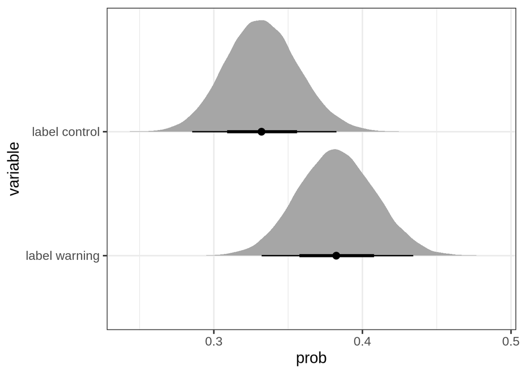

```r
samp_full$label %>%
  mutate(prob = plogis(value)) %>%
  ggplot(aes(y = variable, x = prob)) +
  stat_halfeye()
```

The difference distribution contains 0 for the 95% intervals, but not for the smaller (i.e., 80% or 50%) intervals suggesting some evidence for a backfire effect.

```r
ss <- samp_full$label %>%
  mutate(prob = plogis(value))
levels(ss$variable) <- str_remove(levels(ss$variable), "label ")
ss_diff <- ss %>%
  pivot_wider(id_cols = -value, names_from = variable, values_from = prob) %>%
  mutate(diff = warning - control)
ss_diff %>%
  mean_qi(diff, .width = c(0.5, 0.8, 0.95))
```

```
## # A tibble: 3 x 6
##     diff   .lower .upper .width .point .interval
##    <dbl>    <dbl>  <dbl>  <dbl> <chr>  <chr>
## 1 0.0501  0.0257  0.0745   0.5  mean   qi
## 2 0.0501  0.00375 0.0964   0.8  mean   qi
## 3 0.0501 -0.0213  0.120    0.95 mean   qi
```

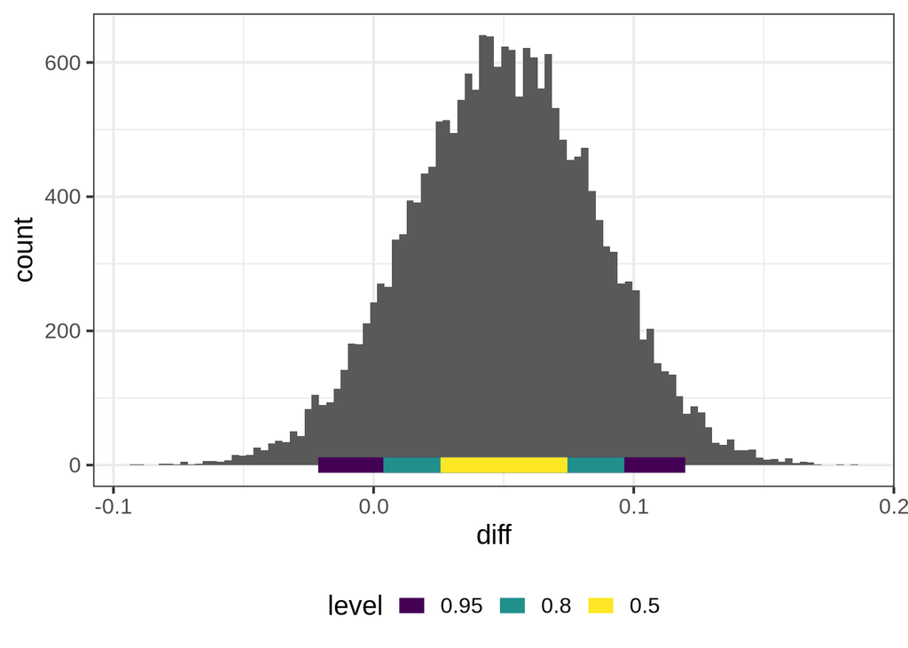

```r
ggplot(ss_diff, aes(diff)) +
  geom_histogram(bins = 100) +
  stat_interval()
```

We can also look at the results for the minimal model.

Again, no obvious problems.

```r
summary(mri)
```

```
##
## Model Info:
##  function:     brms::brm
##  family:       binomial(logit)
##  formula:      nsucc | trials(nt) ~ label * complexity + (1 | newid)
##  algorithm:    sampling
##  chains:       4
##  sample:       20000 (posterior sample size)
##  priors:       Use brms::prior_summary(object) for prior information
##  observations: 1518
##  groups:       newid (506)
##
## Estimate Intercept:
##      Variable   Mean MAD_SD     5%    50%    95%  rhat ess_bulk  ess_tail
## 1 (Intercept) -0.560  0.071 -0.677 -0.560 -0.442 1.000 6681.996 10397.649
##
##
## Estimates 'label' - difference from intercept:
##        Variable   Mean MAD_SD     5%    50%   95%  rhat ess_bulk ess_tail
## 1 label warning  0.102  0.071 -0.016  0.103 0.222 1.001 6075.256 9649.877
## 2 label control -0.102  0.071 -0.222 -0.103 0.016 1.001 6075.256 9649.877
##
## Estimates 'complexity' - difference from intercept:
##            Variable   Mean MAD_SD     5%    50%    95%  rhat  ess_bulk  ess_tail
## 1    complexity low  0.017  0.050 -0.066  0.017  0.100 1.001 31681.941 14381.163
## 2 complexity medium -0.261  0.050 -0.345 -0.261 -0.178 1.000 30948.615 14375.361
## 3   complexity high  0.244  0.049  0.163  0.244  0.325 1.000 31656.440 15033.143
##
## Estimates 'label:complexity' - difference from intercept:
##                           Variable   Mean MAD_SD     5%    50%    95%  rhat  ess_bulk  ess_tail
## 1    label warning, complexity low  0.099  0.100 -0.065  0.099  0.265 1.000  9889.637 13240.822
## 2    label control, complexity low -0.065  0.101 -0.231 -0.066  0.102 1.000 10412.890 13513.613
## 3 label warning, complexity medium -0.094  0.102 -0.260 -0.094  0.074 1.000 10373.159 12603.878
## 4 label control, complexity medium -0.429  0.102 -0.600 -0.428 -0.260 1.000 10152.574 13344.897
## 5   label warning, complexity high  0.302  0.099  0.140  0.302  0.468 1.000  9672.834 12698.474
## 6   label control, complexity high  0.186  0.101  0.019  0.186  0.352 1.000  9564.820 13943.340
```

The results pattern looks like for the maximal model

```r
samp_ri <- stanova_samples(mri, diff_intercept = FALSE,
                             return = "tidybayes")
```

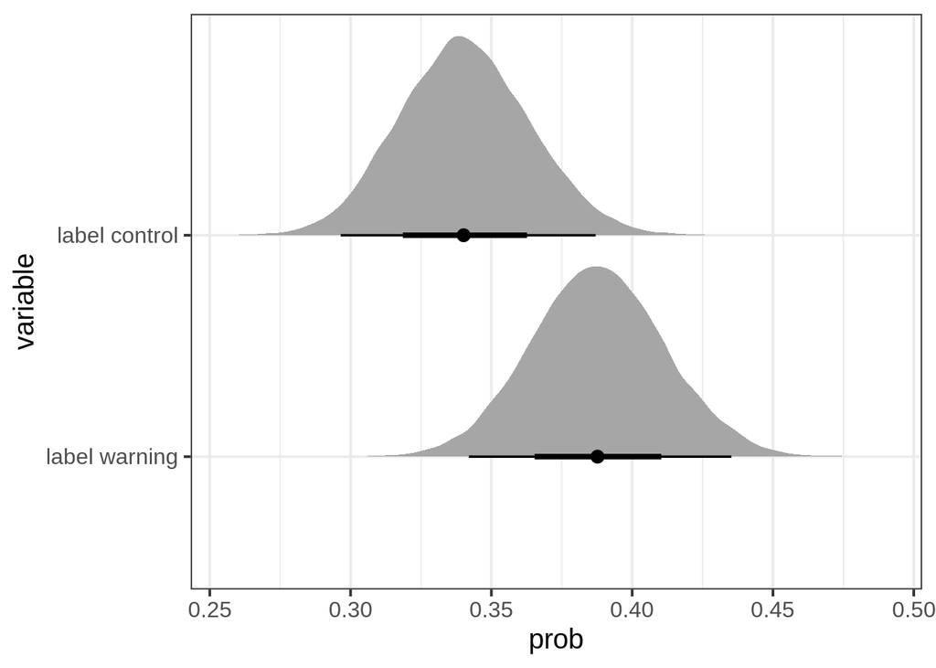

```r
samp_ri$label %>%
  mutate(prob = plogis(value)) %>%
  ggplot(aes(y = variable, x = prob)) +
  stat_halfeye()
```

The difference distribution contains 0 for the 95% intervals, but not for the smaller (i.e., 80% or 50%) intervals suggesting some evidence for a backfire effect.

```r
ss2 <- samp_ri$label %>%
  mutate(prob = plogis(value))
levels(ss2$variable) <- str_remove(levels(ss2$variable), "label ")
ss2_diff <- ss2 %>%
  pivot_wider(id_cols = -value, names_from = variable, values_from = prob) %>%
  mutate(diff = warning - control)
ss2_diff %>%
  mean_qi(diff, .width = c(0.5, 0.8, 0.95))
```

```
## # A tibble: 3 x 6
##     diff   .lower .upper .width .point .interval
##    <dbl>    <dbl>  <dbl>  <dbl> <chr>  <chr>
## 1 0.0473  0.0249  0.0692   0.5  mean   qi
## 2 0.0473  0.00482 0.0903   0.8  mean   qi
## 3 0.0473 -0.0182  0.113    0.95 mean   qi
```

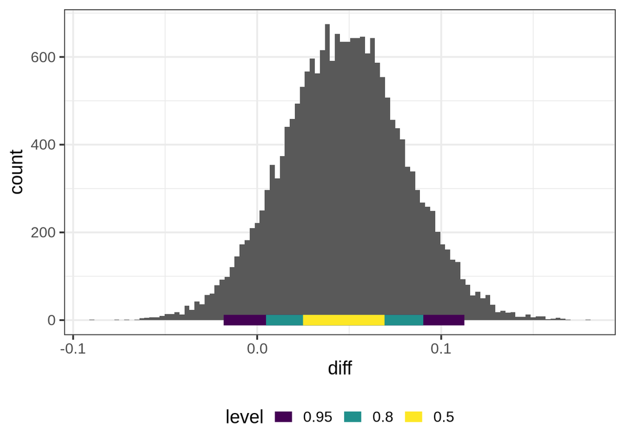

```r
ggplot(ss2_diff, aes(diff)) +
  geom_histogram(bins = 100) +
  stat_interval()
```

We can also take a look at the interaction. Here, we look at the effect of the label for each level of complexity. For simplicity, we only look at the effect on the log odds ratio scale (i.e., not the probability scale).

```r
emmeans(mfull, "label", by = "complexity") %>%
  pairs() %>%
  gather_emmeans_draws() %>%
  mean_qi(.value, .width = c(0.5, 0.8, 0.95))
```

```
## # A tibble: 9 x 8
## # Groups:   contrast [1]
##   contrast          complexity .value   .lower .upper .width .point .interval
##   <fct>             <fct>       <dbl>    <dbl>  <dbl>  <dbl> <chr>  <chr>
## 1 warning - control low         0.137  0.0436   0.229   0.5  mean   qi
## 2 warning - control medium      0.379  0.236    0.523   0.5  mean   qi
## 3 warning - control high        0.141 -0.00821  0.289   0.5  mean   qi
## 4 warning - control low         0.137 -0.0399   0.311   0.8  mean   qi
## 5 warning - control medium      0.379  0.106    0.653   0.8  mean   qi
## 6 warning - control high        0.141 -0.142    0.423   0.8  mean   qi
## 7 warning - control low         0.137 -0.131    0.404   0.95 mean   qi
## 8 warning - control medium      0.379 -0.0348   0.798   0.95 mean   qi
## 9 warning - control high        0.141 -0.293    0.563   0.95 mean   qi
```

```r
emmeans(mri, "label", by = "complexity") %>%
  pairs() %>%
  gather_emmeans_draws() %>%
  mean_qi(.value, .width = c(0.5, 0.8, 0.95))
```

```
## # A tibble: 9 x 8
## # Groups:   contrast [1]
##   contrast          complexity .value    .lower .upper .width .point .interval
##   <fct>             <fct>       <dbl>     <dbl>  <dbl>  <dbl> <chr>  <chr>
## 1 warning - control low         0.163  0.0470    0.279   0.5  mean   qi
## 2 warning - control medium      0.335  0.215     0.454   0.5  mean   qi
## 3 warning - control high        0.116 -0.000821  0.234   0.5  mean   qi
## 4 warning - control low         0.163 -0.0625    0.385   0.8  mean   qi
## 5 warning - control medium      0.335  0.111     0.563   0.8  mean   qi
## 6 warning - control high        0.116 -0.106     0.340   0.8  mean   qi
## 7 warning - control low         0.163 -0.176     0.506   0.95 mean   qi
## 8 warning - control medium      0.335 -0.0156    0.686   0.95 mean   qi
## 9 warning - control high        0.116 -0.227     0.460   0.95 mean   qi
```

These results also do not show a reliable effect of warning label on the 95% scale.

### Main Effects Only

Following the preregistration, we also run a model without the interaction of the fixed effects (i.e., main effects only). We again begin with the maximal random-effects structure justified by the design.

```r
summary(mme_full)
```

```
##
## Model Info:
##  function:     brms::brm
##  family:       binomial(logit)
##  formula:      nsucc | trials(nt) ~ label + complexity + (complexity | newid)
##  algorithm:    sampling
##  chains:       4
##  sample:       20000 (posterior sample size)
##  priors:       Use brms::prior_summary(object) for prior information
##  observations: 1518
##  groups:       newid (506)
##
## Estimate Intercept:
##      Variable   Mean MAD_SD     5%    50%    95%  rhat ess_bulk  ess_tail
## 1 (Intercept) -0.587  0.079 -0.717 -0.586 -0.458 1.000 9994.071 14058.625
##
##
## Estimates 'label' - difference from intercept:
##        Variable   Mean MAD_SD     5%    50%   95%  rhat  ess_bulk  ess_tail
## 1 label warning  0.083  0.066 -0.026  0.083 0.192 1.000 14162.286 14910.479
## 2 label control -0.083  0.066 -0.192 -0.083 0.026 1.000 14162.286 14910.479
##
## Estimates 'complexity' - difference from intercept:
##            Variable   Mean MAD_SD     5%    50%    95%  rhat  ess_bulk  ess_tail
## 1    complexity low  0.109  0.061  0.009  0.108  0.211 1.000 16343.630 16268.628
## 2 complexity medium -0.333  0.058 -0.430 -0.332 -0.239 1.000 28257.334 15342.439
## 3   complexity high  0.224  0.056  0.129  0.225  0.318 1.000 25039.947 15171.320
```

We again see no effect of the warning label (i.e., 95% CI for `label` includes 0).

We can also look at the results for the model without the random slope which shows the same results:

```r
summary(mme_ri)
```

```
##
## Model Info:
##  function:     brms::brm
##  family:       binomial(logit)
##  formula:      nsucc | trials(nt) ~ label + complexity + (1 | newid)
##  algorithm:    sampling
##  chains:       4
##  sample:       20000 (posterior sample size)
##  priors:       Use brms::prior_summary(object) for prior information
##  observations: 1518
##  groups:       newid (506)
##
## Estimate Intercept:
##      Variable   Mean MAD_SD     5%    50%    95%  rhat ess_bulk  ess_tail
## 1 (Intercept) -0.559  0.072 -0.679 -0.558 -0.441 1.000 7136.695 10597.647
##
##
## Estimates 'label' - difference from intercept:
##        Variable   Mean MAD_SD     5%    50%   95%  rhat ess_bulk  ess_tail
## 1 label warning  0.100  0.072 -0.018  0.100 0.216 1.000 7505.023 11796.976
## 2 label control -0.100  0.072 -0.216 -0.100 0.018 1.000 7505.023 11796.976
##
## Estimates 'complexity' - difference from intercept:
##            Variable   Mean MAD_SD     5%    50%    95%  rhat  ess_bulk  ess_tail
## 1    complexity low  0.016  0.050 -0.065  0.016  0.098 1.000 38367.308 14744.868
## 2 complexity medium -0.260  0.050 -0.344 -0.260 -0.176 1.000 33868.716 13875.223
## 3   complexity high  0.243  0.050  0.162  0.243  0.325 1.001 38482.608 13966.403
```

### Single Fixed-Effect Only

As a final test of, we also run an analysis on a model that only included a single fixed-effect.

We also need to aggregate the data to sample efficiently.

```r
dla2 <- dl %>%
  group_by(label, newid) %>%
  summarise(acc = mean(response),
            nsucc = sum(response == 1),
            nt = n()) %>%
  ungroup
```

We begin with a model that only includes fixed-effects for label and by-participant random intercepts.

```r
summary(mfe)
```

```
##
## Model Info:
##  function:     brms::brm
##  family:       binomial(logit)
##  formula:      nsucc | trials(nt) ~ label + (1 | newid)
##  algorithm:    sampling
##  chains:       4
##  sample:       20000 (posterior sample size)
##  priors:       Use brms::prior_summary(object) for prior information
##  observations: 506
##  groups:       newid (506)
##
## Estimate Intercept:
##      Variable   Mean MAD_SD     5%    50%    95%  rhat ess_bulk  ess_tail
## 1 (Intercept) -0.553  0.071 -0.670 -0.553 -0.436 1.000 6591.922 10527.464
##
##
## Estimates 'label' - difference from intercept:
##        Variable   Mean MAD_SD     5%    50%   95%  rhat ess_bulk  ess_tail
## 1 label warning  0.098  0.071 -0.018  0.097 0.217 1.000 6248.671 10477.960
## 2 label control -0.098  0.071 -0.217 -0.097 0.018 1.000 6248.671 10477.960
```

This model converged successfully, but showed no effect of label.

## Compare Predicted and Observed

For generalized linear mixed models the predicted marginal means do not necessarily have to correspond to the observed marginal means, especially for lower-order terms. Consequently, it makes sense to compare both observed and predicted means to see whether both agree qualitatively and quantitatively. If there are large disagreements, results should be interpreted carefully.

### Label

First we check the agreement for the effect of label. We compare the observed mean proportions against the predictions of three models. The maximal model with interaction, the minimal model with interaction, and the main-effect only model (i.e., only fixed-effect is label).

```r
dl %>%
  group_by(label) %>%
  summarise(prop = mean(response)) %>%
  mutate(
    full = get_est(emmeans(mfull, "label", type = "response")),
    minimal = get_est(emmeans(mri, "label", type = "response")),
    me_only = get_est(emmeans(mfe, "label", type = "response")),
  )
```

```
## # A tibble: 2 x 5
##   label    prop full               minimal            me_only
##   <fct>   <dbl> <chr>              <chr>              <chr>
## 1 warning 0.413 0.38 [0.33,  0.43] 0.39 [0.34,  0.44] 0.39 [0.34,  0.43]
## 2 control 0.378 0.33 [0.28,  0.38] 0.34 [0.30,  0.39] 0.34 [0.30,  0.39]
```

For the effect of label, the predicted response proportions are consistently smaller than the observed response proportions. In addition, there are rather small differences between the different models. This suggests that the main difference between model and data is due to the random-effects. Nevertheless, observed and predicted response proportions agree qualitatively. When the warning label is present, the proportion of betting seems to be slightly larger (note that this difference is NOT significant).

## Model Evaluation

All models show at least qualitative agreement between observed and predicted response proportions, so we would be willing to interpret the results.

In terms of effects tests, the different models agree as well. There is no evidence for an effect of label. Furthermore, if anything, there is a backfire effect that the warning label increases gambling.

Given the very strong agreement in, the choice of which model is the “best” seems not particularly consequential. Here we use the maximal model.

## Figure

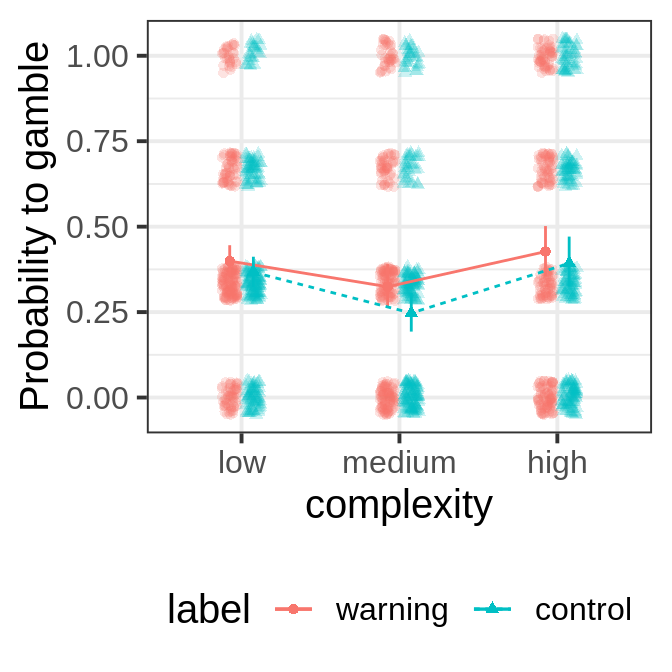

```r
afex_plot(mfull, "complexity", "label", dodge = 0.3,
          data_alpha = 0.2, mapping = c("linetype", "fill", "color", "shape"),
          data_arg = list(
            position =
              ggplot2::position_jitterdodge(
                jitter.width = 0.2,
                jitter.height = 0.05,
                dodge.width = 0.3  ## needs to be same as dodge
                )), dv = "acc", data = dla, id = "newid") +
  ylab("Probability to gamble")
```

We also create a figure for the paper.

```
## NOTE: Results may be misleading due to involvement in interactions
```

```
## Renaming/reordering factor levels of 'label':
##   warning -> Warning
##   control -> Control
```

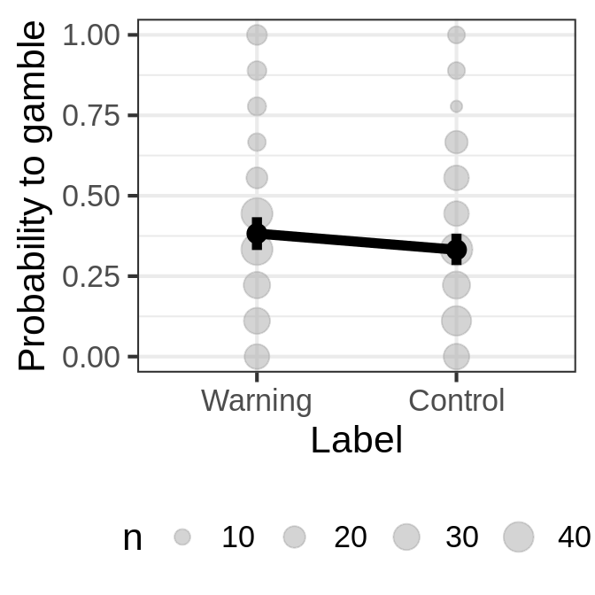

```r
theme_set(theme_bw(base_size = 16) +
            theme(legend.position="bottom"))

afex_plot(mfull, "label",
          mapping = c(""),
          data_geom = geom_count,
          data_arg = list(color = "darkgrey"),
          point_arg = list(size = 3.5),
          error_arg = list(size = 2, width = 0),
          factor_levels = list(label = c("Warning", "Control")),
          dv = "response", data = dl, id = "newid") +
  ylab("Probability to gamble") + xlab("Label") +
  guides(shape = FALSE) +
  scale_size_area() +
  geom_line(aes(group = 1), size = 2)
```

```r
 ggsave("plot1.png", device = "png",
       width = 9, height = 9, units = "cm",
       dpi = 600)
```

## Effect Size

The effect size for binomial data is odds ratio (OR).

```r
emmeans(mfull, c("label"), type = "response") %>%
  pairs %>%
  update(by = NULL) %>%
  summary(adjust = "holm", infer = TRUE)
```

```
## NOTE: Results may be misleading due to involvement in interactions
```

```
##  contrast          odds.ratio lower.HPD upper.HPD
##  warning / control       1.25     0.887      1.65
##
## Point estimate displayed: median
## Results are back-transformed from the log odds ratio scale
## HPD interval probability: 0.95
```

For reference, again the predicted marginal means of the model.

```r
emmeans(mfull, c("label"), type = "response")
```

```
## NOTE: Results may be misleading due to involvement in interactions
```

```
##  label    prob lower.HPD upper.HPD
##  warning 0.382     0.331     0.433
##  control 0.332     0.285     0.382
##
## Point estimate displayed: median
## Results are back-transformed from the logit scale
## HPD interval probability: 0.95
```

# Exploratory Analysis

Following our preregistration, we also inspect whether the additional covariates affect the probability to gamble.

```r
dfull <- left_join(dla, add_vars, by = "newid")
## remove participant where gender is na
dfull2 <- dfull %>%
  filter(!is.na(gender)) %>%
  droplevels
covariates <- c("gender", "age_z", "freq_z", "psg_z")
```

## Gender

```r
summary(mgender_main)
```

```
##
## Model Info:
##  function:     brms::brm
##  family:       binomial(logit)
##  formula:      nsucc | trials(nt) ~ label * complexity + gender + (complexity |
##     newid)
##  algorithm:    sampling
##  chains:       4
##  sample:       20000 (posterior sample size)
##  priors:       Use brms::prior_summary(object) for prior information
##  observations: 1515
##  groups:       newid (505)
##
## Estimate Intercept:
##      Variable   Mean MAD_SD     5%    50%    95%  rhat  ess_bulk  ess_tail
## 1 (Intercept) -0.570  0.082 -0.704 -0.570 -0.436 1.000 10372.470 13574.400
##
##
## Estimates 'label' - difference from intercept:
##        Variable   Mean MAD_SD     5%    50%   95%  rhat ess_bulk  ess_tail
## 1 label warning  0.106  0.079 -0.023  0.106 0.237 1.000 9624.754 12806.369
## 2 label control -0.106  0.079 -0.237 -0.106 0.023 1.000 9624.754 12806.369
##
## Estimates 'complexity' - difference from intercept:
##            Variable   Mean MAD_SD     5%    50%    95%  rhat  ess_bulk  ess_tail
## 1    complexity low  0.108  0.060  0.010  0.108  0.208 1.000 16402.249 15253.884
## 2 complexity medium -0.335  0.058 -0.430 -0.335 -0.241 1.000 28181.260 15162.952
## 3   complexity high  0.227  0.057  0.134  0.227  0.319 1.000 26365.297 15166.065
##
## Estimates 'gender' - difference from intercept:
##        Variable   Mean MAD_SD     5%    50%   95%  rhat  ess_bulk  ess_tail
## 1   gender Male  0.039  0.070 -0.077  0.039 0.155 1.000 13965.950 15033.930
## 2 gender Female -0.039  0.070 -0.155 -0.039 0.077 1.000 13965.950 15033.930
##
## Estimates 'label:complexity' - difference from intercept:
##                           Variable   Mean MAD_SD     5%    50%    95%  rhat  ess_bulk  ess_tail
## 1    label warning, complexity low  0.175  0.091  0.023  0.175  0.324 1.000 16618.571 16845.846
## 2    label control, complexity low  0.041  0.091 -0.112  0.042  0.191 1.000 16930.795 16741.807
## 3 label warning, complexity medium -0.149  0.120 -0.349 -0.149  0.048 1.000 13745.036 14798.760
## 4 label control, complexity medium -0.521  0.123 -0.725 -0.520 -0.318 1.000 13193.837 13500.300
## 5   label warning, complexity high  0.292  0.122  0.089  0.293  0.493 1.000 12036.246 14764.002
## 6   label control, complexity high  0.162  0.123 -0.042  0.162  0.365 1.000 12547.488 15025.852
```

```r
summary(mgender_inter)
```

```
##
## Model Info:
##  function:     brms::brm
##  family:       binomial(logit)
##  formula:      nsucc | trials(nt) ~ label * complexity * gender + (complexity |
##     newid)
##  algorithm:    sampling
##  chains:       4
##  sample:       20000 (posterior sample size)
##  priors:       Use brms::prior_summary(object) for prior information
##  observations: 1515
##  groups:       newid (505)
##
## Estimate Intercept:
##      Variable   Mean MAD_SD     5%    50%    95%  rhat  ess_bulk  ess_tail
## 1 (Intercept) -0.543  0.083 -0.680 -0.544 -0.408 1.000 11052.737 13442.576
##
##
## Estimates 'label' - difference from intercept:
##        Variable   Mean MAD_SD     5%    50%   95%  rhat  ess_bulk  ess_tail
## 1 label warning  0.105  0.082 -0.029  0.104 0.240 1.001 10717.436 14141.023
## 2 label control -0.105  0.082 -0.240 -0.104 0.029 1.001 10717.436 14141.023
##
## Estimates 'complexity' - difference from intercept:
##            Variable   Mean MAD_SD     5%    50%    95%  rhat  ess_bulk  ess_tail
## 1    complexity low  0.071  0.064 -0.033  0.071  0.177 1.000 16648.962 16324.546
## 2 complexity medium -0.326  0.060 -0.427 -0.325 -0.228 1.000 28382.380 15858.072
## 3   complexity high  0.255  0.060  0.154  0.255  0.354 1.000 24190.059 16491.628
##
## Estimates 'gender' - difference from intercept:
##        Variable   Mean MAD_SD     5%    50%   95%  rhat  ess_bulk  ess_tail
## 1   gender Male  0.130  0.082 -0.007  0.131 0.267 1.000 10107.786 13338.429
## 2 gender Female -0.130  0.082 -0.267 -0.131 0.007 1.000 10107.786 13338.429
##
## Estimates 'label:complexity' - difference from intercept:
##                           Variable   Mean MAD_SD     5%    50%    95%  rhat  ess_bulk  ess_tail
## 1    label warning, complexity low  0.147  0.098 -0.013  0.148  0.309 1.000 19293.967 17304.383
## 2    label control, complexity low -0.005  0.097 -0.164 -0.005  0.154 1.000 17185.310 17348.682
## 3 label warning, complexity medium -0.146  0.127 -0.356 -0.146  0.064 1.000 14297.709 14447.464
## 4 label control, complexity medium -0.505  0.126 -0.714 -0.504 -0.300 1.000 14382.555 15747.911
```

[output cut: 31 more lines]

```
## 11   label warning, complexity high, gender Female  0.158  0.173 -0.131  0.158  0.448 1.000
## 12   label control, complexity high, gender Female -0.102  0.183 -0.406 -0.102  0.198 1.000
##     ess_bulk  ess_tail
## 1  23485.426 17257.819
## 2  19962.195 17561.732
## 3  12448.008 14357.701
## 4  11964.598 15677.154
## 5  11420.276 14517.568
## 6  11781.022 15144.987
## 7  14752.692 16588.378
## 8  15223.631 15994.446
## 9  13378.698 14067.413
## 10 14790.250 16027.568
## 11 12790.795 15255.704
## 12 13728.281 15148.681
```

For gender, neither model shows an effect of `label`. However, in the model with interaction, the control condition for female participants is below the intercept. Does this mean that we see a differential label effect for gender?

```r
emmeans(mgender_inter, "label", by = "gender", type = "response") %>%
  gather_emmeans_draws() %>%
  mutate(prob = plogis(.value)) %>%
  mutate(lab_gend = label:gender) %>%
  ungroup %>%
  compare_levels(prob, by = lab_gend) %>%
  median_qi() %>%
  slice(c(2,5))
```

```
## NOTE: Results may be misleading due to involvement in interactions
```

```
## # A tibble: 2 x 7
##   lab_gend                           prob .lower .upper .width .point .interval
##   <chr>                             <dbl>  <dbl>  <dbl>  <dbl> <chr>  <chr>
## 1 control:Female - warning:Female -0.0599 -0.144 0.0234   0.95 median qi
## 2 control:Male - warning:Male     -0.0362 -0.160 0.0905   0.95 median qi
```

As this table shows, the difference between the two labels includes 0 for either gender. Hence, there is no evidence for a differential effect of label across genders.

## Age

```r
summary(mage_main)
```

```
##
## Model Info:
##  function:     brms::brm
##  family:       binomial(logit)
##  formula:      nsucc | trials(nt) ~ label * complexity + age_z + (complexity |
##     newid)
##  algorithm:    sampling
##  chains:       4
##  sample:       20000 (posterior sample size)
##  priors:       Use brms::prior_summary(object) for prior information
##  observations: 1515
##  groups:       newid (505)
##
## Estimate Intercept:
##      Variable   Mean MAD_SD     5%    50%    95%  rhat  ess_bulk  ess_tail
## 1 (Intercept) -0.582  0.078 -0.713 -0.581 -0.453 1.000 10699.141 13388.773
##
##
## Estimates 'label' - difference from intercept:
##        Variable   Mean MAD_SD     5%    50%   95%  rhat  ess_bulk  ess_tail
## 1 label warning  0.105  0.078 -0.022  0.105 0.237 1.000 10447.586 13177.735
## 2 label control -0.105  0.078 -0.237 -0.105 0.022 1.000 10446.681 13214.271
##
## Estimates 'complexity' - difference from intercept:
##            Variable   Mean MAD_SD     5%    50%    95%  rhat  ess_bulk  ess_tail
## 1    complexity low  0.108  0.061  0.009  0.108  0.209 1.000 17005.073 16344.128
## 2 complexity medium -0.335  0.057 -0.429 -0.335 -0.241 1.000 28919.025 16605.886
## 3   complexity high  0.227  0.058  0.131  0.227  0.322 1.000 27506.358 15519.535
##
## Estimates 'age_z' - trend ('age_z'):
##   Variable   Mean MAD_SD     5%    50%   95%  rhat  ess_bulk  ess_tail
## 1    age_z -0.006  0.067 -0.118 -0.006 0.102 1.000 16082.547 15811.414
##
## Estimates 'label:complexity' - difference from intercept:
##                           Variable   Mean MAD_SD     5%    50%    95%  rhat  ess_bulk  ess_tail
## 1    label warning, complexity low  0.173  0.092  0.024  0.173  0.324 1.000 17770.523 16793.444
## 2    label control, complexity low  0.043  0.093 -0.110  0.044  0.196 1.000 17106.824 17312.822
## 3 label warning, complexity medium -0.149  0.119 -0.347 -0.149  0.050 1.000 13761.293 15382.917
## 4 label control, complexity medium -0.521  0.122 -0.726 -0.518 -0.319 1.000 14896.015 14018.403
## 5   label warning, complexity high  0.292  0.125  0.088  0.291  0.499 1.000 13304.541 14969.662
## 6   label control, complexity high  0.162  0.124 -0.045  0.163  0.366 1.000 13595.045 14764.735
```

```r
summary(mage_inter)
```

```
##
## Model Info:
##  function:     brms::brm
##  family:       binomial(logit)
##  formula:      nsucc | trials(nt) ~ label * complexity * age_z + (complexity |
##     newid)
##  algorithm:    sampling
##  chains:       4
##  sample:       20000 (posterior sample size)
##  priors:       Use brms::prior_summary(object) for prior information
##  observations: 1515
##  groups:       newid (505)
##
## Estimate Intercept:
##      Variable   Mean MAD_SD     5%    50%    95%  rhat ess_bulk  ess_tail
## 1 (Intercept) -0.587  0.077 -0.717 -0.587 -0.459 1.000 8886.040 12497.614
##
##
## Estimates 'label' - difference from intercept:
##        Variable   Mean MAD_SD     5%    50%   95%  rhat ess_bulk  ess_tail
## 1 label warning  0.110  0.077 -0.017  0.109 0.238 1.000 7844.650 12373.897
## 2 label control -0.110  0.077 -0.238 -0.109 0.017 1.000 7848.318 12389.445
##
## Estimates 'complexity' - difference from intercept:
##            Variable   Mean MAD_SD     5%    50%    95%  rhat  ess_bulk  ess_tail
## 1    complexity low  0.113  0.060  0.013  0.113  0.213 1.000 14833.909 14385.164
## 2 complexity medium -0.334  0.058 -0.431 -0.334 -0.240 1.000 27430.940 15631.588
## 3   complexity high  0.221  0.057  0.127  0.221  0.315 1.001 25144.594 15547.643
##
## Estimates 'age_z' - trend ('age_z'):
##   Variable   Mean MAD_SD     5%    50%   95%  rhat ess_bulk  ess_tail
## 1    age_z -0.073  0.077 -0.203 -0.073 0.055 1.000 8782.073 12601.671
##
## Estimates 'label:complexity' - difference from intercept:
##                           Variable   Mean MAD_SD     5%    50%    95%  rhat  ess_bulk  ess_tail
## 1    label warning, complexity low  0.177  0.092  0.026  0.177  0.329 1.000 15281.805 16373.394
## 2    label control, complexity low  0.048  0.093 -0.103  0.048  0.200 1.000 16020.971 16510.648
## 3 label warning, complexity medium -0.142  0.119 -0.339 -0.141  0.052 1.000 11555.035 14804.317
## 4 label control, complexity medium -0.526  0.123 -0.729 -0.525 -0.326 1.000 11657.887 14521.875
## 5   label warning, complexity high  0.295  0.122  0.096  0.294  0.497 1.000 10942.776 14138.397
## 6   label control, complexity high  0.148  0.123 -0.056  0.148  0.351 1.000 10504.183 14120.304
##
## Estimates 'label:age_z' - trend ('age_z'):
##        Variable   Mean MAD_SD     5%    50%    95%  rhat ess_bulk  ess_tail
## 1 label warning  0.103  0.110 -0.075  0.103  0.283 1.001 8641.841 12659.511
## 2 label control -0.248  0.112 -0.437 -0.248 -0.062 1.000 9039.640 12941.452
##
## Estimates 'complexity:age_z' - trend ('age_z'):
##            Variable   Mean MAD_SD     5%    50%    95%  rhat  ess_bulk  ess_tail
## 1    complexity low  0.018  0.069 -0.097  0.018  0.133 1.000 17022.413 16524.515
## 2 complexity medium -0.052  0.104 -0.228 -0.052  0.125 1.000 10774.944 13127.583
## 3   complexity high -0.184  0.109 -0.366 -0.184 -0.003 1.000  9961.659 13567.668
##
## Estimates 'label:complexity:age_z' - trend ('age_z'):
##                           Variable   Mean MAD_SD     5%    50%    95%  rhat  ess_bulk  ess_tail
## 1    label warning, complexity low  0.038  0.097 -0.124  0.038  0.196 1.000 16617.086 16153.268
## 2    label control, complexity low -0.002  0.101 -0.165 -0.001  0.162 1.000 17506.214 16790.226
## 3 label warning, complexity medium  0.192  0.150 -0.051  0.191  0.436 1.000 10670.883 14501.325
## 4 label control, complexity medium -0.296  0.154 -0.558 -0.294 -0.040 1.001 11141.100 14372.474
## 5   label warning, complexity high  0.078  0.154 -0.171  0.078  0.330 1.000  9855.476 12509.788
## 6   label control, complexity high -0.447  0.160 -0.714 -0.445 -0.185 1.000 10166.441 12930.378
```

For age we also find that the CIs for the main effect of `label` still includes 0 in all cases.

## Gambling Frequency

```r
summary(mfreq_main)
```

```
##
## Model Info:
##  function:     brms::brm
##  family:       binomial(logit)
##  formula:      nsucc | trials(nt) ~ label * complexity + freq_z + (complexity |
##     newid)
##  algorithm:    sampling
##  chains:       4
##  sample:       20000 (posterior sample size)
##  priors:       Use brms::prior_summary(object) for prior information
##  observations: 1515
##  groups:       newid (505)
##
## Estimate Intercept:
##      Variable   Mean MAD_SD     5%    50%    95%  rhat  ess_bulk  ess_tail
## 1 (Intercept) -0.584  0.079 -0.713 -0.583 -0.457 1.001 10149.497 13324.085
##
##
## Estimates 'label' - difference from intercept:
##        Variable   Mean MAD_SD     5%    50%   95%  rhat ess_bulk  ess_tail
## 1 label warning  0.104  0.078 -0.023  0.105 0.233 1.001 9957.821 12309.656
## 2 label control -0.104  0.078 -0.233 -0.105 0.023 1.001 9958.192 12246.099
##
## Estimates 'complexity' - difference from intercept:
##            Variable   Mean MAD_SD     5%    50%    95%  rhat  ess_bulk  ess_tail
## 1    complexity low  0.109  0.061  0.010  0.109  0.210 1.000 16582.372 15833.394
## 2 complexity medium -0.335  0.058 -0.431 -0.335 -0.241 1.000 27635.282 15701.049
## 3   complexity high  0.226  0.057  0.131  0.226  0.319 1.000 27232.190 14698.404
##
## Estimates 'freq_z' - trend ('freq_z'):
##   Variable   Mean MAD_SD     5%    50%   95%  rhat  ess_bulk  ess_tail
## 1   freq_z -0.054  0.066 -0.165 -0.054 0.055 1.000 14194.367 14827.566
##
## Estimates 'label:complexity' - difference from intercept:
##                           Variable   Mean MAD_SD     5%    50%    95%  rhat  ess_bulk  ess_tail
## 1    label warning, complexity low  0.175  0.091  0.025  0.174  0.325 1.000 18205.084 16890.338
## 2    label control, complexity low  0.044  0.091 -0.108  0.044  0.195 1.000 18180.963 17685.296
## 3 label warning, complexity medium -0.151  0.118 -0.346 -0.151  0.043 1.001 13721.196 15905.027
## 4 label control, complexity medium -0.519  0.123 -0.723 -0.519 -0.320 1.000 13738.121 14500.966
## 5   label warning, complexity high  0.290  0.122  0.085  0.290  0.490 1.001 12566.349 12982.794
## 6   label control, complexity high  0.162  0.124 -0.041  0.163  0.362 1.000 12978.832 15097.112
```

```r
summary(mfreq_inter)
```

```
##
## Model Info:
##  function:     brms::brm
##  family:       binomial(logit)
##  formula:      nsucc | trials(nt) ~ label * complexity * freq_z + (complexity |
##     newid)
##  algorithm:    sampling
##  chains:       4
##  sample:       20000 (posterior sample size)
##  priors:       Use brms::prior_summary(object) for prior information
##  observations: 1515
##  groups:       newid (505)
##
## Estimate Intercept:
##      Variable   Mean MAD_SD     5%    50%    95%  rhat ess_bulk  ess_tail
## 1 (Intercept) -0.587  0.078 -0.714 -0.587 -0.457 1.000 9880.899 13114.797
##
##
## Estimates 'label' - difference from intercept:
##        Variable   Mean MAD_SD     5%    50%   95%  rhat  ess_bulk  ess_tail
## 1 label warning  0.104  0.078 -0.024  0.104 0.232 1.000 10554.438 13066.580
## 2 label control -0.104  0.078 -0.232 -0.104 0.024 1.000 10554.593 13066.580
##
## Estimates 'complexity' - difference from intercept:
##            Variable   Mean MAD_SD     5%    50%    95%  rhat  ess_bulk  ess_tail
## 1    complexity low  0.109  0.060  0.012  0.109  0.209 1.000 16271.944 16073.459
## 2 complexity medium -0.336  0.057 -0.430 -0.336 -0.243 1.000 27487.226 16742.380
## 3   complexity high  0.227  0.057  0.132  0.228  0.320 1.000 25591.822 15708.371
##
## Estimates 'freq_z' - trend ('freq_z'):
##   Variable   Mean MAD_SD     5%    50%    95%  rhat  ess_bulk  ess_tail
## 1   freq_z -0.156  0.080 -0.289 -0.155 -0.028 1.001 10929.968 13630.519
##
## Estimates 'label:complexity' - difference from intercept:
##                           Variable   Mean MAD_SD     5%    50%    95%  rhat  ess_bulk  ess_tail
## 1    label warning, complexity low  0.174  0.090  0.028  0.174  0.323 1.000 18147.585 17682.223
## 2    label control, complexity low  0.044  0.091 -0.107  0.044  0.194 1.000 16858.512 16577.407
## 3 label warning, complexity medium -0.153  0.120 -0.350 -0.153  0.043 1.000 14165.835 14973.606
## 4 label control, complexity medium -0.520  0.122 -0.721 -0.518 -0.323 1.000 15191.296 15774.446
## 5   label warning, complexity high  0.290  0.122  0.087  0.290  0.494 1.000 13541.742 15089.848
## 6   label control, complexity high  0.163  0.124 -0.041  0.165  0.365 1.000 13301.107 15112.415
##
## Estimates 'label:freq_z' - trend ('freq_z'):
##        Variable   Mean MAD_SD     5%    50%    95%  rhat  ess_bulk  ess_tail
## 1 label warning -0.237  0.113 -0.423 -0.237 -0.054 1.001 10914.239 13580.090
## 2 label control -0.075  0.111 -0.258 -0.074  0.107 1.000 11510.308 14464.691
##
## Estimates 'complexity:freq_z' - trend ('freq_z'):
##            Variable   Mean MAD_SD     5%    50%    95%  rhat  ess_bulk  ess_tail
## 1    complexity low -0.018  0.070 -0.135 -0.018  0.096 1.000 19085.439 17601.446
## 2 complexity medium -0.205  0.107 -0.385 -0.205 -0.028 1.001 12917.143 15341.971
## 3   complexity high -0.245  0.112 -0.432 -0.244 -0.063 1.000 12368.463 14193.950
##
## Estimates 'label:complexity:freq_z' - trend ('freq_z'):
##                           Variable   Mean MAD_SD     5%    50%    95%  rhat  ess_bulk  ess_tail
## 1    label warning, complexity low -0.171  0.101 -0.336 -0.171 -0.007 1.000 19592.351 16826.616
## 2    label control, complexity low  0.135  0.096 -0.023  0.134  0.293 1.000 19417.782 17725.978
## 3 label warning, complexity medium -0.251  0.151 -0.506 -0.249  0.000 1.000 12730.783 14839.056
## 4 label control, complexity medium -0.159  0.153 -0.412 -0.157  0.088 1.000 13631.442 15797.850
## 5   label warning, complexity high -0.290  0.158 -0.555 -0.289 -0.034 1.001 12412.776 14878.216
## 6   label control, complexity high -0.200  0.156 -0.458 -0.199  0.055 1.000 13161.475 15780.387
```

For gambling frequency we also find that the CIs for the main effect of `label` still includes 0 in all cases.

## PSG

```r
summary(mpsg_main)
```

```
##
## Model Info:
##  function:     brms::brm
##  family:       binomial(logit)
##  formula:      nsucc | trials(nt) ~ label * complexity + psg_z + (complexity |
##     newid)
##  algorithm:    sampling
##  chains:       4
##  sample:       20000 (posterior sample size)
##  priors:       Use brms::prior_summary(object) for prior information
##  observations: 1515
##  groups:       newid (505)
##
## Estimate Intercept:
##      Variable   Mean MAD_SD     5%    50%    95%  rhat ess_bulk  ess_tail
## 1 (Intercept) -0.583  0.079 -0.712 -0.582 -0.456 1.000 9208.585 12345.656
##
##
## Estimates 'label' - difference from intercept:
##        Variable   Mean MAD_SD     5%    50%   95%  rhat ess_bulk  ess_tail
## 1 label warning  0.104  0.078 -0.024  0.104 0.235 1.000 9369.911 13181.457
## 2 label control -0.104  0.078 -0.235 -0.104 0.024 1.000 9370.875 13181.457
##
## Estimates 'complexity' - difference from intercept:
##            Variable   Mean MAD_SD     5%    50%    95%  rhat  ess_bulk  ess_tail
## 1    complexity low  0.109  0.060  0.010  0.108  0.210 1.000 15860.545 14902.023
## 2 complexity medium -0.335  0.057 -0.430 -0.334 -0.242 1.000 28572.900 15752.360
## 3   complexity high  0.226  0.057  0.133  0.226  0.320 1.000 26527.497 15965.369
##
## Estimates 'psg_z' - trend ('psg_z'):
##   Variable   Mean MAD_SD     5%    50%   95%  rhat  ess_bulk  ess_tail
## 1    psg_z -0.003  0.066 -0.114 -0.003 0.107 1.000 13514.685 15194.997
##
## Estimates 'label:complexity' - difference from intercept:
##                           Variable   Mean MAD_SD     5%    50%    95%  rhat  ess_bulk  ess_tail
## 1    label warning, complexity low  0.174  0.091  0.022  0.174  0.327 1.001 16719.891 16143.258
## 2    label control, complexity low  0.044  0.093 -0.107  0.044  0.196 1.000 16512.117 16253.402
## 3 label warning, complexity medium -0.151  0.119 -0.349 -0.151  0.044 1.000 13024.401 15442.578
## 4 label control, complexity medium -0.519  0.122 -0.720 -0.518 -0.320 1.000 13236.347 14367.918
## 5   label warning, complexity high  0.291  0.124  0.090  0.290  0.492 1.000 12363.766 14780.452
## 6   label control, complexity high  0.162  0.124 -0.044  0.163  0.364 1.000 12289.612 15420.251
```

```r
summary(mpsg_inter)
```

```
##
## Model Info:
##  function:     brms::brm
##  family:       binomial(logit)
##  formula:      nsucc | trials(nt) ~ label * complexity * psg_z + (complexity |
##     newid)
##  algorithm:    sampling
##  chains:       4
##  sample:       20000 (posterior sample size)
##  priors:       Use brms::prior_summary(object) for prior information
##  observations: 1515
##  groups:       newid (505)
##
## Estimate Intercept:
##      Variable   Mean MAD_SD     5%    50%    95%  rhat ess_bulk  ess_tail
## 1 (Intercept) -0.586  0.079 -0.718 -0.586 -0.457 1.000 9817.855 12494.213
##
##
## Estimates 'label' - difference from intercept:
##        Variable   Mean MAD_SD     5%    50%   95%  rhat  ess_bulk  ess_tail
## 1 label warning  0.104  0.078 -0.025  0.105 0.234 1.000 10228.202 13894.535
## 2 label control -0.104  0.078 -0.233 -0.105 0.025 1.000 10228.600 13894.524
##
## Estimates 'complexity' - difference from intercept:
##            Variable   Mean MAD_SD     5%    50%    95%  rhat  ess_bulk  ess_tail
## 1    complexity low  0.110  0.061  0.010  0.110  0.210 1.000 16107.581 16720.026
## 2 complexity medium -0.337  0.058 -0.434 -0.336 -0.240 1.000 28156.426 15090.603
## 3   complexity high  0.227  0.056  0.133  0.227  0.321 1.000 25723.623 15519.655
##
## Estimates 'psg_z' - trend ('psg_z'):
##   Variable  Mean MAD_SD     5%   50%   95%  rhat  ess_bulk  ess_tail
## 1    psg_z 0.035  0.078 -0.094 0.035 0.163 1.000 11609.519 13583.646
##
## Estimates 'label:complexity' - difference from intercept:
##                           Variable   Mean MAD_SD     5%    50%    95%  rhat  ess_bulk  ess_tail
## 1    label warning, complexity low  0.175  0.092  0.025  0.174  0.325 1.000 17441.784 17867.772
## 2    label control, complexity low  0.046  0.093 -0.108  0.046  0.197 1.000 17609.615 17303.426
## 3 label warning, complexity medium -0.151  0.120 -0.353 -0.149  0.045 1.000 14204.002 16065.128
## 4 label control, complexity medium -0.522  0.123 -0.723 -0.522 -0.319 1.000 14154.794 15629.926
## 5   label warning, complexity high  0.290  0.124  0.086  0.291  0.492 1.000 13025.821 14543.228
## 6   label control, complexity high  0.164  0.124 -0.041  0.165  0.364 1.000 13639.742 15371.667
##
## Estimates 'label:psg_z' - trend ('psg_z'):
##        Variable  Mean MAD_SD     5%   50%   95%  rhat  ess_bulk  ess_tail
## 1 label warning 0.051  0.111 -0.132 0.052 0.232 1.000 11308.233 13703.044
## 2 label control 0.019  0.111 -0.164 0.019 0.202 1.000 11429.528 13799.076
##
## Estimates 'complexity:psg_z' - trend ('psg_z'):
##            Variable   Mean MAD_SD     5%    50%   95%  rhat  ess_bulk  ess_tail
## 1    complexity low -0.020  0.069 -0.135 -0.020 0.095 1.000 20859.696 17156.145
## 2 complexity medium -0.011  0.108 -0.190 -0.010 0.165 1.000 13769.794 15832.872
## 3   complexity high  0.136  0.111 -0.043  0.135 0.317 1.000 13007.387 15226.292
##
## Estimates 'label:complexity:psg_z' - trend ('psg_z'):
##                           Variable   Mean MAD_SD     5%    50%   95%  rhat  ess_bulk  ess_tail
## 1    label warning, complexity low -0.115  0.099 -0.281 -0.114 0.046 1.000 19928.228 16245.799
## 2    label control, complexity low  0.075  0.099 -0.086  0.075 0.240 1.000 19890.203 16715.599
## 3 label warning, complexity medium  0.070  0.148 -0.180  0.070 0.313 1.000 13249.353 14619.941
## 4 label control, complexity medium -0.092  0.153 -0.348 -0.090 0.161 1.000 14199.644 16016.438
## 5   label warning, complexity high  0.198  0.156 -0.055  0.197 0.455 1.000 12677.592 13446.579
## 6   label control, complexity high  0.073  0.156 -0.182  0.072 0.332 1.000 12839.965 14945.667
```

For PSG we also find that the CIs for the main effect of `label` still includes 0 in all cases.